# AFA - 2nd Session

Mathis Mourey

6 février 2020

# R for AFA - 2nd session - More dealing with data

We’re going to start off with getting data from the quantmod API.

```r
library(quantmod)
stocks = c('AAPL', 'FB')


get_data = function(stocks){
  df = data.frame(matrix(nrow=300, ncol=length(stocks)))
  r=1
  for(i in stocks){
    df[,r] = tail(getSymbols(i, env=NULL)[,6], 300)
    r = r + 1
  }
  colnames(df) = stocks
  return (df)
}

df = get_data(stocks)
```

[output not shown]

```r
head(df)
```

```
##       AAPL     FB
## 1 53.36796 189.93
## 2 53.61062 186.82
## 3 53.35571 181.28
## 4 54.17683 182.80
## 5 53.89740 180.11
## 6 53.63513 177.10
```

```r
p_to_r = function(df){
  rt = data.frame(matrix(nrow=nrow(df), ncol=ncol(df)))
  for(i in 1:ncol(df)){
    rt[,i] = diff(log(df[,i]))
  }
  rt = rt[-1,]
  colnames(rt) = colnames(df)
  return(rt)
}

rt = p_to_r(df)
head(rt)
```

```
##           AAPL           FB
## 2  0.004536692 -0.016509922
## 3 -0.004766313 -0.030102832
## 4  0.015272345  0.008349884
## 5 -0.005170939 -0.014824895
## 6 -0.004878012 -0.016853202
## 7  0.023262653  0.005518320
```

# Know your data: plot it first

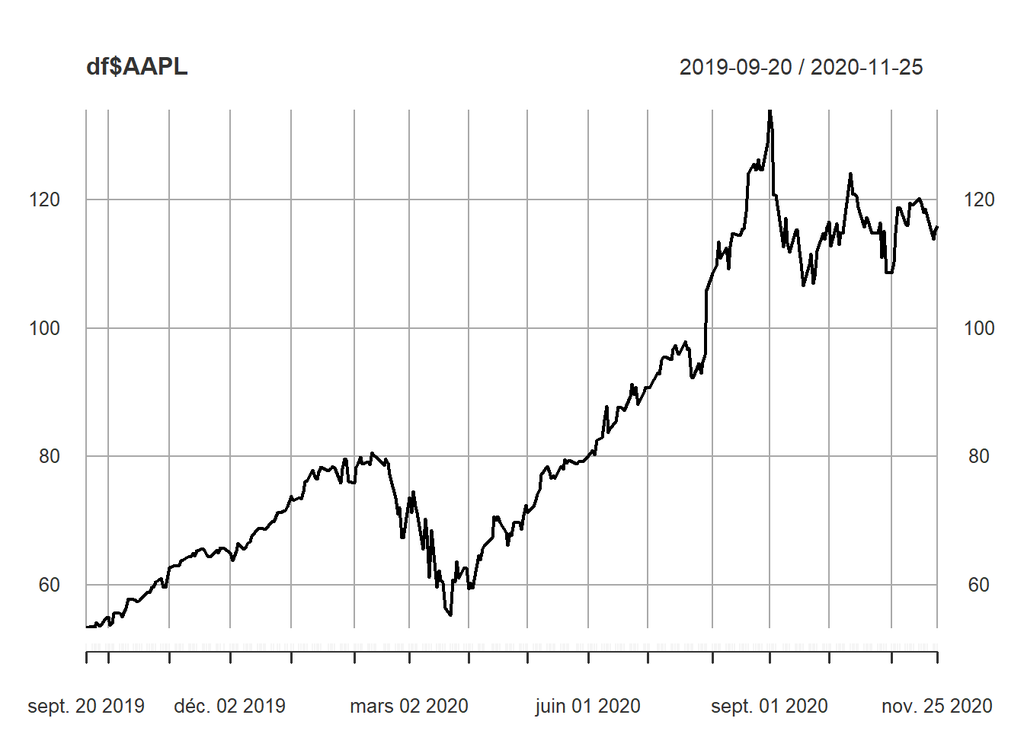

```r
plot(df$AAPL)
```

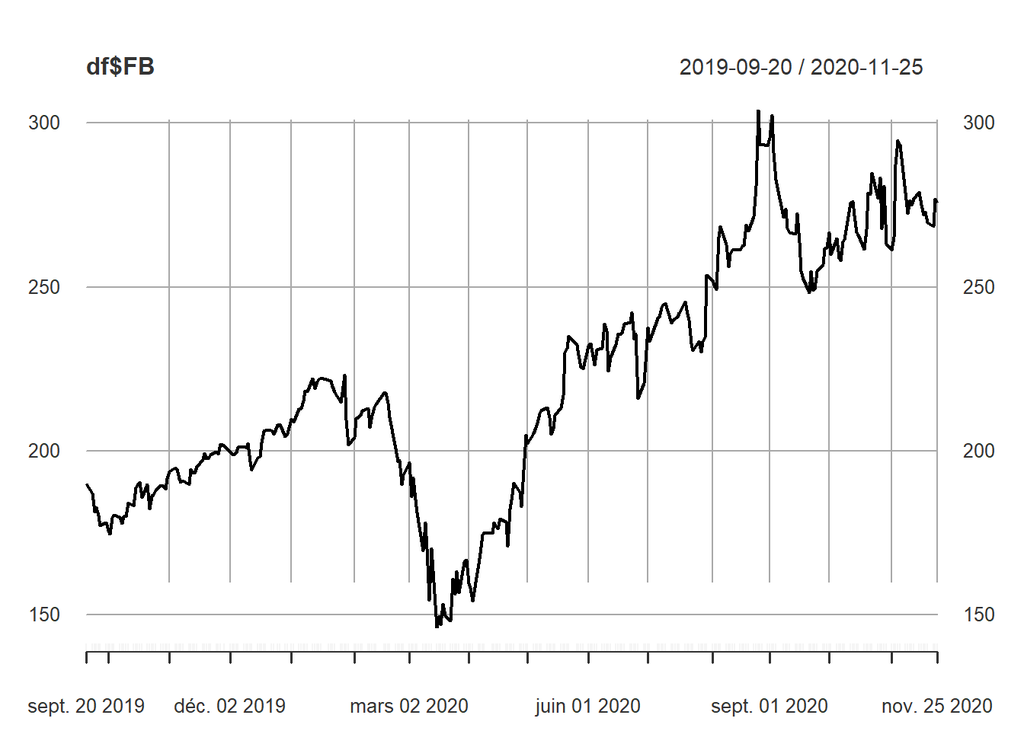

```r
plot(df$FB)
```

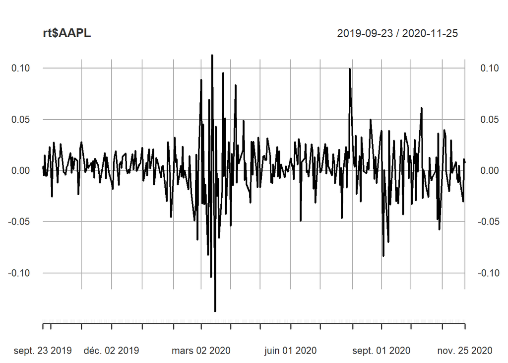

```r
plot(rt$AAPL)
```

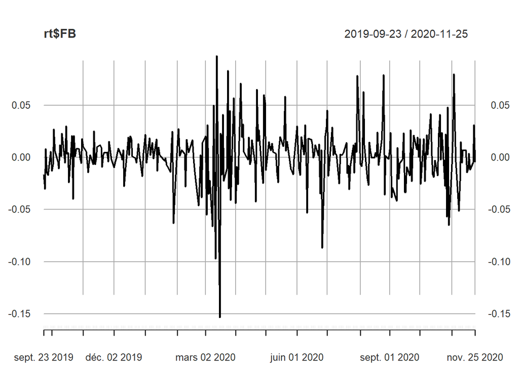

```r
plot(rt$FB)
```

## Boxplots, Pirate plots, Density and other usefull visualization.

```r
library(yarrr)
```

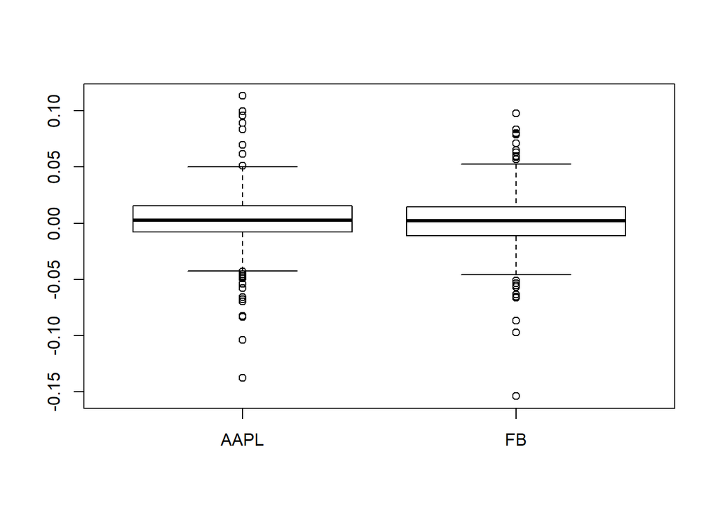

```r
boxplot(as.matrix(rt))
```

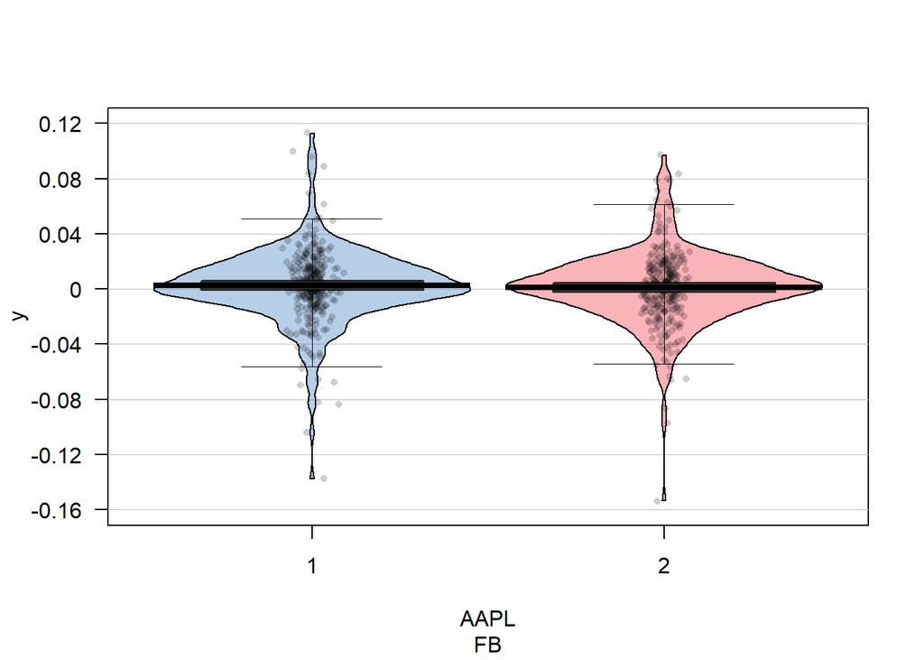

```r
pirateplot(data=rt,
           xlab=colnames(rt),
           quant = c(.025, .975), # 10th and 90th quantiles
           quant.col = "black")
```

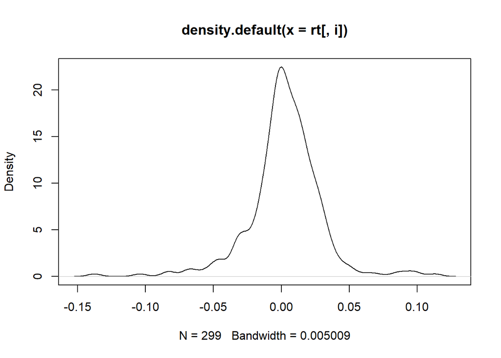

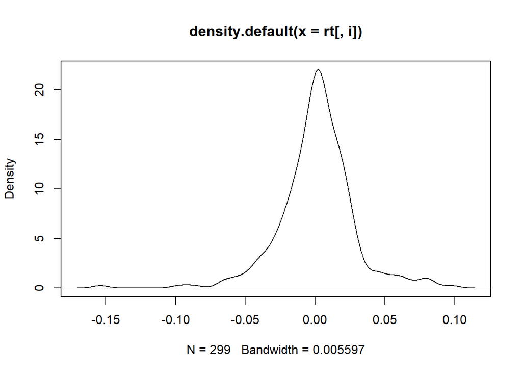

```r
for(i in 1:ncol(rt)){
  plot(density(rt[,i]))
}
```

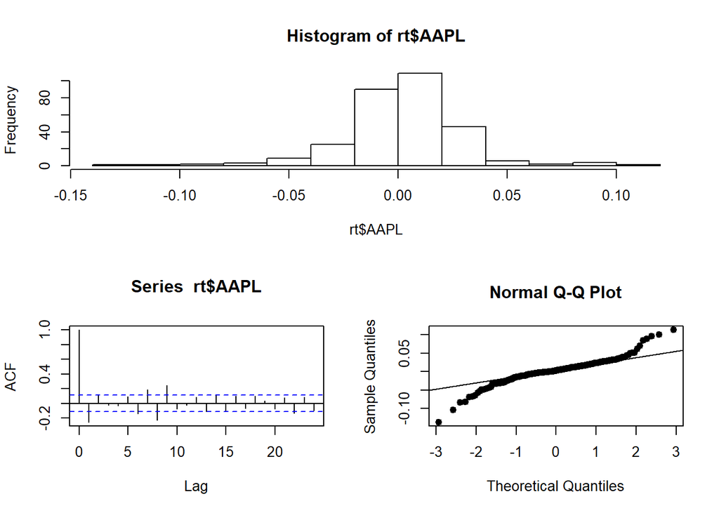

```r
layout(rbind(c(1, 1), c(2, 3)))


hist(rt$AAPL)
acf(rt$AAPL)
qqnorm(rt$AAPL, pch = 19)
qqline(rt$AAPL)
```

## R for AFA - 2nd session - Missing data

How to deal with missing data ? This is a central issue when we use financial data. There could be (and most probably there will be) missing data in your dataset. First, there is no good way to deal with missing data. Each method can be debated and have drawbacks for sure. In pratice there is three ways to deal with NAs.

1. **Only use complete cases** :This means to ignore any observations with missing data. It obviously works the best when there is only very few of missing datas. Moreover, it can biased the values of estimators. By selecting only available values, are you describing the actual relationships exisitng or the relationship only for fully observable variables?
2. **Remove predictors with NAs** : Quite a simple solutions as well. Should be used in priority when one predictor contains a lot of missing cases.
3. **Imputation of NAs** : Find a statistical model that allows you to create artificial data to remplace the missing cases. The simplest case is the linear regression. This method applies to datasets containing lot of missing data a bit everywhere.

What to do when there is a lot of NAs everywhere then ? Simple. Don’t do the analysis. The results will not provide you any good information anyways. Keep in mind that the purpose of statistics is to give you significant information from the data. In order to do so, it needs proper data. Cleaning your dataset (one of the three options above) before starting any analysis is fundamental !

```r
library(openxlsx)
df = read.xlsx('missing_dataAFA.xlsx', sheet= 'Company_data')
df
```

```
##     Instrument Normalized.EBIT Total.Current.Assets Company.Market.Cap
## 1          ABT      4670000000          15667000000       1.891988e+11
## 2       ABBV.K     13540000000          49519000000       1.590291e+11
## 3       ABMD.O       249219000            635863000       1.194068e+10
## 4          ACN      6305074000          15450601000       1.502569e+11
## 5       ATVI.O      1739000000           7292000000       6.181923e+10
## 6       ADBE.O      3439021000           6494925000       2.242675e+11
## 7        AMD.O       583000000           4597000000       8.797207e+10
## 8          AAP       754483000           5695543000       1.063907e+10
## 9          AES      2158000000           5231000000       1.249781e+10
## 10         AFL      3444296000                   NA       2.694809e+10
## 11           A      1059000000           3189000000       3.063981e+10
## 12         APD      2169000000           4618300000       6.534277e+10
## 13      AKAM.O       583518000           2231613000       1.774459e+10
## 14         ALK      1105000000           2037000000       5.074175e+09
```

[output cut: 86 more lines]

```r
library(Hmisc)
describe(df)
```

```
## df
##
##  4  Variables      100  Observations
## ---------------------------------------------------------------------------
## Instrument
##        n  missing distinct
##      100        0      100
##
## lowest : A      AAL.O  AAP    AAPL.O ABBV.K, highest: KMX    LNT.O  MO     SCHW.K T
## ---------------------------------------------------------------------------
## Normalized.EBIT
##         n   missing  distinct      Info      Mean       Gmd       .05
##        94         6        93         1 4.729e+09 6.503e+09 4.094e+08
##       .10       .25       .50       .75       .90       .95
## 5.378e+08 8.111e+08 1.613e+09 3.443e+09 9.598e+09 2.205e+10
##
## lowest :   -64174000   168699000   249219000   254461000   366800000
## highest: 17228000000 31001000000 32874000000 35928000000 63930000000
## ---------------------------------------------------------------------------
## Total.Current.Assets
##         n   missing  distinct      Info      Mean       Gmd       .05
##        88        12        87         1 1.524e+10 2.196e+10 7.197e+08
##       .10       .25       .50       .75       .90       .95
## 1.250e+09 2.214e+09 4.608e+09 9.989e+09 3.002e+10 8.178e+10
##
## lowest : 6.77060e+07 4.58031e+08 5.68248e+08 6.07600e+08 6.35863e+08
## highest: 5.47610e+10 9.63340e+10 1.02229e+11 1.52578e+11 1.62819e+11
## ---------------------------------------------------------------------------
## Company.Market.Cap
##         n   missing  distinct      Info      Mean       Gmd       .05
##       100         0        99         1  1.01e+11 1.508e+11 7.268e+09
##       .10       .25       .50       .75       .90       .95
## 9.845e+09 1.484e+10 2.657e+10 6.664e+10 1.511e+11 2.391e+11
##
## lowest : 4.774852e+09 5.074175e+09 5.199856e+09 6.707929e+09 7.153594e+09
## highest: 2.242675e+11 5.213207e+11 9.899480e+11 1.480084e+12 1.827235e+12
## ---------------------------------------------------------------------------
```

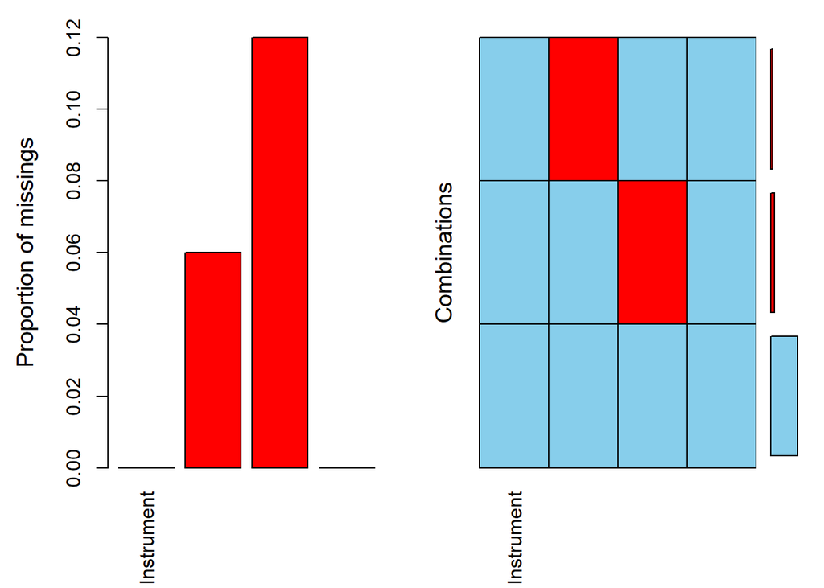

```r
library(VIM)
aggr(df)
```

```r
library(lmtest)
res = lm(Company.Market.Cap ~ Normalized.EBIT + Total.Current.Assets, data=df, na.action = na.omit)
summary(res)
```

```
##
## Call:
## lm(formula = Company.Market.Cap ~ Normalized.EBIT + Total.Current.Assets,
##     data = df, na.action = na.omit)
##
## Residuals:
##        Min         1Q     Median         3Q        Max
## -4.326e+11 -1.852e+10  1.012e+10  2.332e+10  8.985e+11
##
## Coefficients:
##                        Estimate Std. Error t value Pr(>|t|)
## (Intercept)          -2.068e+10  1.690e+10  -1.223 0.224889
## Normalized.EBIT       1.394e+01  3.407e+00   4.093 0.000102 ***
## Total.Current.Assets  4.147e+00  9.828e-01   4.220 6.47e-05 ***
## ---
## Signif. codes:  0 '***' 0.001 '**' 0.01 '*' 0.05 '.' 0.1 ' ' 1
##
## Residual standard error: 1.371e+11 on 79 degrees of freedom
##   (18 observations deleted due to missingness)
## Multiple R-squared:  0.7848, Adjusted R-squared:  0.7794
## F-statistic: 144.1 on 2 and 79 DF,  p-value: < 2.2e-16
```

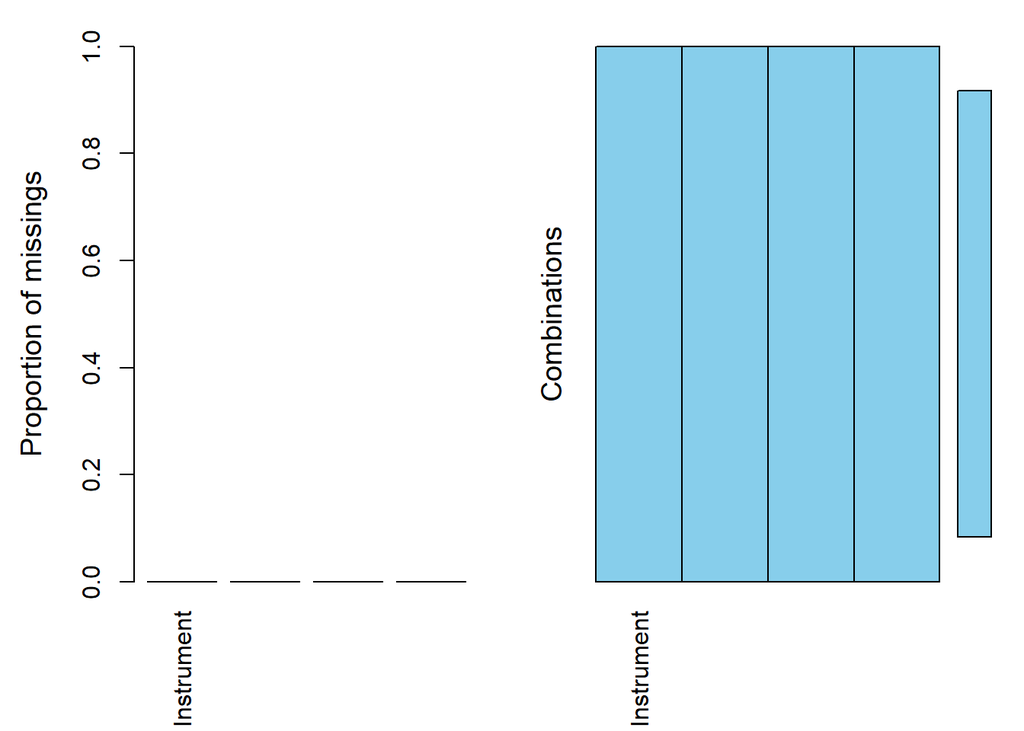

```r
m_coef = res$coefficients
m_resid = mean(res$residuals)

for (i in 1:nrow(df)){
  if (is.na(df$Normalized.EBIT[i])==T){
    df$Normalized.EBIT[i] = (df$Company.Market.Cap[i] - m_coef[3]*df$Total.Current.Assets[i] - m_coef[1] - m_resid)/m_coef[2]
  } else if (is.na(df$Total.Current.Assets[i])==T){
    df$Total.Current.Assets[i] = (df$Company.Market.Cap[i] - m_coef[2]*df$Normalized.EBIT[i] - m_coef[1] - m_resid)/m_coef[3]
  }
}

aggr(df)
```